# GCDS: Data Visualization and the Grammar of Graphics

# **Overview**

Data visualization is key to understanding data. This exercise will use `dplyr` most prominently. Piecing together the components will be difficult but in the end you need visualizations. At very least you should gain an understanding of chaining functions together in `dplyr` using the `%>%` from the `magrittr` library in order to set by step manipulate a data frame.

Some Helpful Functions:

- `ggplot()`: for initializing a plot object
- `aes()`: for specifying aesthetics of a plot (e.g., x, y, size, color, etc.)
- `geom_bar()`: for bar geometry of a plot using either x or y
- `geom_col()`: for bar geometry of a plot using x and y
- `geom_point()`: for point geometry of a plot
- `geom_line()`: for line geometry of a plot
- `geom_histogram()`: for a distribution geometry of a plot
- `ggtitle()` or `labs()`: for adding a title
- `geom_text()`: for editing text
- `ylab()` and `xlab()`: for axis labeling
- `coord_flip()`: for flipping the x and y coordinates
- `theme_minimal()`: a particular theme application
- `theme_set()`: for setting a theme

# **Loading Libraries**

You will need to load `dplyr` and `ggplot2`.

```r
library(ggplot2)
library(dplyr)
```

# **Example: An XY Scatterplot**

Here is an example of a scatterplot communicating the relationship between `mpg` and `cyl` (cylinder size) from the `mtcars` data set. The plot uses two data frames, one of which summarizes the `mpg` means for each `cyl` level. Yes, you can use two data frames in the same plot.

[figure not shown]

```r
mt_means <- mtcars %>% group_by(., cyl) %>% summarise(., mean = mean(mpg))

ggplot(mtcars) +
  geom_point(aes(x = factor(cyl),
                 y = mpg,
                 color = factor(cyl)),
             shape = 22, position = "jitter") +
  geom_point(data = mt_means,
             mapping = aes(x = factor(cyl),
                           y = mean,
                           color = factor(cyl)),
             alpha = .60,
             size = 3) +
  labs(title = "Relationship between Cylinder and MPG") +
  xlab("Cylinder") +
  ylab("Miles Per Gallon") +
  scale_color_discrete(name = "Cylinders",
                       #breaks = c(8,6,4),
                       labels = c("8 Cylinder","6 Cylinder","4 Cylinder")) +
  see::theme_modern()
```

# **The Grammar of Graphics**

In [*The Grammar of Graphics* (Wilkinson, 2005)] (https://www.amazon.com/Grammar-Graphics-Statistics-Computing/dp/0387245448), Wilkinson explains how graphics can be created using layers that build upon each other.

Plot layers build, starting with data:

- theme
- coordinates
- statistics
- facets
- geometries
- aesthetics
- data

# **`ggplot` Plot Basics**

`ggplot2` was created based on Wilkinsons’s grammar structure, so all plots using `ggplot2` start with a base foundation, on top which layers are added according to their own aesthetic attributes.

As Hadley Wickham points out in *ggplot2: Elegant Graphics for Data Analysis, Second Edition*, that the original Grammar of Graphics put forth by Wilkinson and later on the layered grammar of graphics, a statistical graphic represents a *mapping from data to aesthetic attributes* (e.g., color, size, shape, etc.) of geometric objects (e.g., points, lines, bars, etc.) plotted on a specific coordinate system (e.g., Cartesian, Polar). Plots may include statistical information or text. Facetting methods can be used to produce the same plots for different subsets of data (e.g., variations in another variable). All of these individual components comprised to create the final graphic.

Applying a set of rules, or a grammar, allows for creating plot of all different types. Just like understanding a grammar allows you to create new sentences that have never been spoken before, knowing the grammar of graphics allows you to create plots that have not been created before. Without a grammar, you may be limited to choose a sentence structure from a database that matches most closely to what you want to say even. Unfortunately, there may not be an appropriate sentence in that database. If you are programming visualizations, you may be limited need to use a function (like a sentence) that someone has written to plot some data even if the plot is not what you want to create. A grammar will free you of these limitations.

All plots will follow the same rules, so applying the rules allows you to create visualizations never seen before.

Note: Using a grammar needs to be correct even if the sentence is nonsensical.

## *`ggplot` Plot Composition*

- *Data* containing numeric, character, factor variables to visualize
- *Layers* containing geometric elements and statistical transformations
- *Scales* that map values in the data space to values in aesthetic space
- *A Coordinate System* for mapping coordinates to the plane of a graphic
- *A facet* for plotting subsets of data
- *A theme* controlling the niceties of the plot, like font, backround, etc.

The grammar does not:

- Make suggestions about what graphics to use
- Describe interactivity with a graphic; ggplot2 graphics are static images

Note: For interactive graphics, see `GGobi`, or similar libraries.

## *Initializing the Plot Object*

What is a `?ggplot` object? Review the docs first. Let’s apply the base layer using `ggplot()`. This function takes a data set and simply initializes the plot object so that you can build other on top of it. By default, `data = NULL` so, you will need to pass some data argument. There is also a `mapping` parameter for mapping the aesthetics of the plot, by default, `mapping = aes()`. If you don’t pass a data frame to `data`, what happens?

```r
#?ggplot
ggplot()
```

## *Passing the Data*

You cannot have a plot without data, so we need to pass something to `data`.

```r
DATA <- data.frame(
  A = c(1, 2, 3, 4),
  B = c(2, 5, 3, 8),
  C = c(10, 15, 32, 28),
  D = c("Task A", "Task A", "Task B", "Task B"),
  E = c("circle", "circle", "square", "square")
  )
```

```r
ggplot(data = DATA)
```

```r
# or GAME_DAT_choice %>% ggplot()
```

OK, so still nothing. That’s because we haven’t told `ggplot` what visual properties or aesthetics to include. Importantly, we don’t have do this in a base layer. If we set `data = DATA`, the subsequent layers will inherit that data frame if you don’t pass the argument in a different layer. However, you are not limited to passing only one data set. You might wish to plot the aesthetics of one data frame in one layer and then add another layer of aesthetics taken from a different data frame. TLDR; you can pass data or not in the initialization of the base layer.

## *Scaling/Scale Transformation*

```r
print(DATA)
```

```
##   A B  C      D      E
## 1 1 2 10 Task A circle
## 2 2 5 15 Task A circle
## 3 3 3 32 Task B square
## 4 4 8 28 Task B square
```

Looking at the data, we have columns and rows. Looking at the data frame, you see the ‘identity’ of each case. Ease case is a numeric value, character, or factor. What you for each is there identity. Of course, we can change their identity in some way by transforming the values to z scores, log values, or each average them together to take their count and then plot those data. But those are not their true identity.

In order to take the data units in the data frame so that they can be represented as physical units on a plot (e.g., points, bars, lines, etc.), there needs to be some scaling transformation. The plot needs to understand how many pixels high and wide to create a plot and the plot needs to know the limits of the axes for example. Similarly, it needs to know what shapes to present, how many, etc. By default, the statistical transformation is an ‘identity’ transformation, of one that just takes the values and plots them as their appear in the data (their identity).

## *Choosing a Coordinate System*

All we have now is the base layer taking on some coordinates. For example, where are the points plotted on the plot? The system can follow the Cartesian coordinate system or a Polar coordinate system. An example of this will follow later. For now, the default is chosen for you.

## *Adding Aesthetic Mappings*

If you wanted a plot geometry to inherit properties of the initialized base layer, you could pass aesthetics to the mapping argument, `mapping = aes()`.

```r
ggplot(data = DATA, mapping = aes())
```

But this doesn’t do anything because we haven’t added information to pass to the aesthetics in `aes()`. Looking at `?aes`, we see that `aes()` maps how properties of the data connect to or map onto with the features of the graph (e.g., axis position, color, size, etc.). The aesthetics are the visual properties of the plots, so they are essential to map by passing arguments to `aes()`. But how many and what variables do we reference? Looking at `?aes`, you see that x and y are needed.

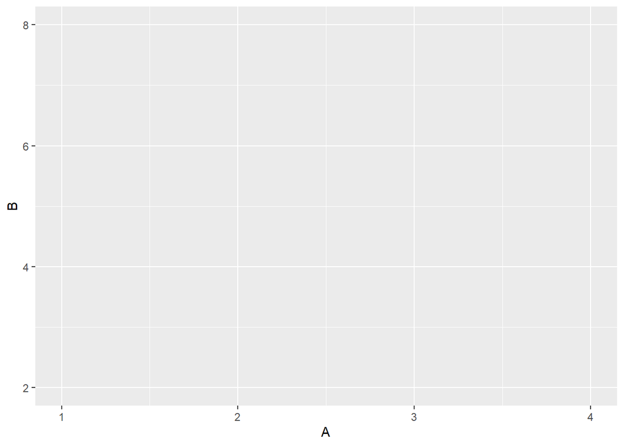

```r
ggplot(data = DATA,
       mapping = aes(x = A, y = B)
       )
```

We can see that the aesthetic layer now applied to the plot scales the data to present `A` along the x-axis with a range from lowest to highest value from that vector. Similarly, the mapping presents `B` along the y-axis with a range from lowest to highest value in the vector. Also, the aesthetics include the variable name as a the label for the x and y axes. Of course, these could be changed in a layer as well. More on that later.

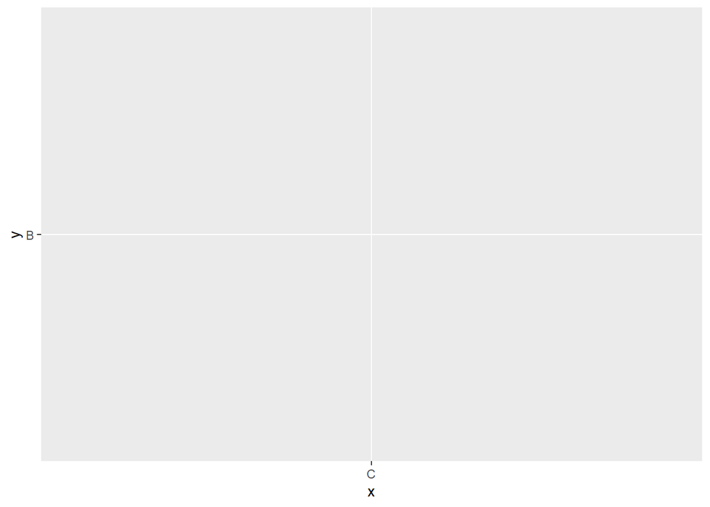

```r
ggplot(data = DATA,
       mapping = aes(x = "C", y = "B")
       )
```

If we want to plot the data as they are in the data frame, we would apply the ‘identity’ transformation. By identity, we just need to instruct `ggplot` to use the data values in the data set. If you wanted to plot the means, frequency count, or something else, we would need to tell `ggplot` how to transform the data.

## *Adding Plot Geometries*

We don’t yet have any geometries, or *geoms*, added. Geoms can take many forms, including, points, lines, bars, text, etc. If we want the values in `A` and `B` to be plotted as x and y coordinates representing points on the plot, we can add a point geometry using `geom_point()`.

```r
ggplot(data = DATA,
       mapping = aes(x = A, y = B)
       ) +
  geom_point()
```

[output not shown]

The points geometry has now been applied, which takes the aesthetic mapping and makes them into points.

But geometries also have aesthetics, or visual properties so for each geom, you can pass arguments to `aes()`. For example, the xy points have to take some shape, color, and size in order for them to be visible. By default, these have been determined or otherwise you wouldn’t see black circles of any size.

Checking `?geom_point`, you will see at the bottom of the arguments section, that by default `inherit.aes = TRUE`, which means the aesthetic mappings in `geom_point()` will be inherited by default. Similarly, `data = NULL` so the data and the aesthetic mapping from `ggplot()` don’t need to be specified as `data = DATA` and `mapping = aes(x = A, y = B)`, unless of course we wanted to overwrite them. Though not inherited, other aesthetics have defaults for `geom_point()`. If we wanted to be verbose, we could include all of them and see how this plot compares with that above.

```r
ggplot(data = DATA,
       mapping = aes(x = A, y = B)
       ) +
  geom_point(mapping = aes(x = A, y = B),
             data = NULL,
             stat = "identity",
             position = "identity",
             size = 1.5)
```

[output not shown]

### *How and Where to Map Aesthetics?*

You might be wondering how you map these aesthetic properties so that when you attempt to do so, you don’t get a bunch of errors. There are two places you can map aesthetics:

Either in the initialized plot object:

- **`ggplot(data = data, mapping = aes(x, y))`** `+ geom_point()`

Or in the geometry:

- `ggplot() +`**`geom_point(data = data, mapping = aes(x, y))`**

We can map aesthetics in the initialize plot object by also assigning this to an object named `map` just so we can reference it as need. When we do this mapping…

```r
map <- ggplot(data = DATA,
              mapping = aes(A, C))
```

The aesthetics are inherited by the geometries that follow, which then do not require any mapping of their own…

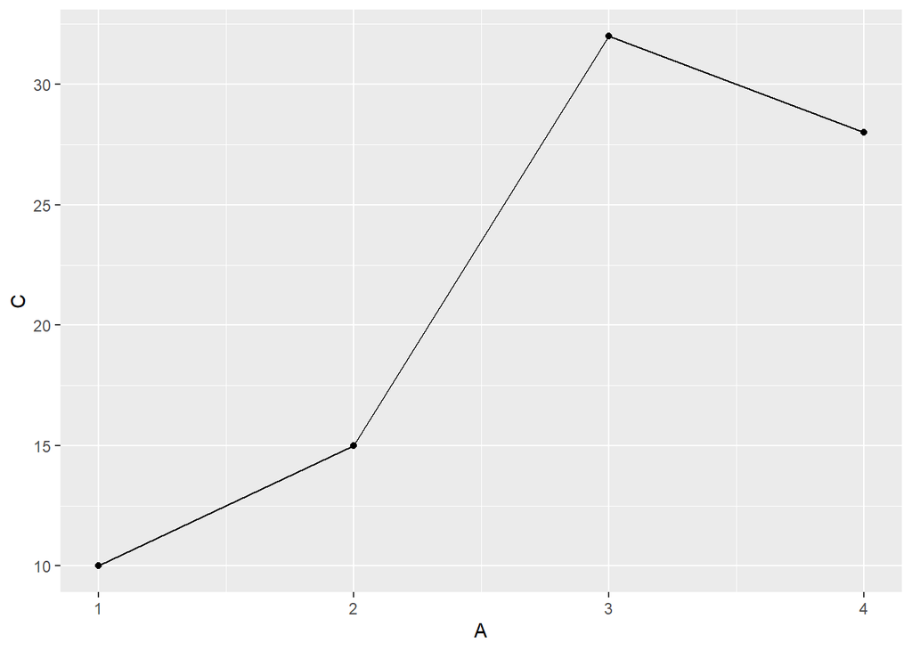

```r
map +
  geom_point() +
  geom_line()
```

But when aesthetics are NOT mapped in initialized plot…

```r
map <- ggplot()
```

There are no aesthetics to be inherited by the plot geometry functions because they are not passed to the `ggplot()` object. In this case they must be mapped as arguments the geometries themselves.

Plot points…

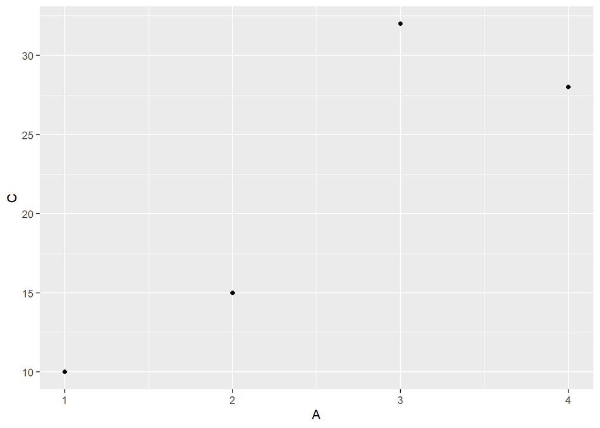

```r
map +
  geom_point(data = DATA,
             mapping = aes(A, C))
```

Plot a line…

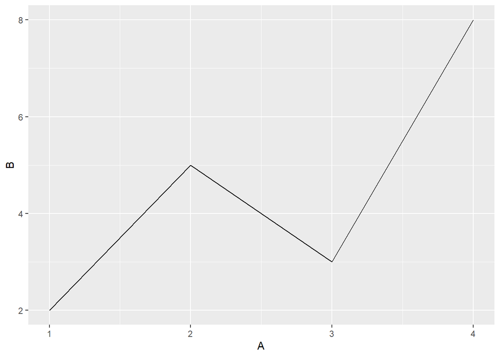

```r
map +
  geom_line(data = DATA,
            mapping = aes(x = A, y = B))
```

In a later section, we will differentiate between setting and mapping aesthetic attributes.

*Add labels, a coordinate system, scaling, and a theme*

Pretty much the same? For completeness, there are also x and y label layers and a coordinate system also applied by default. Let’s add them to the plot by adding layers.

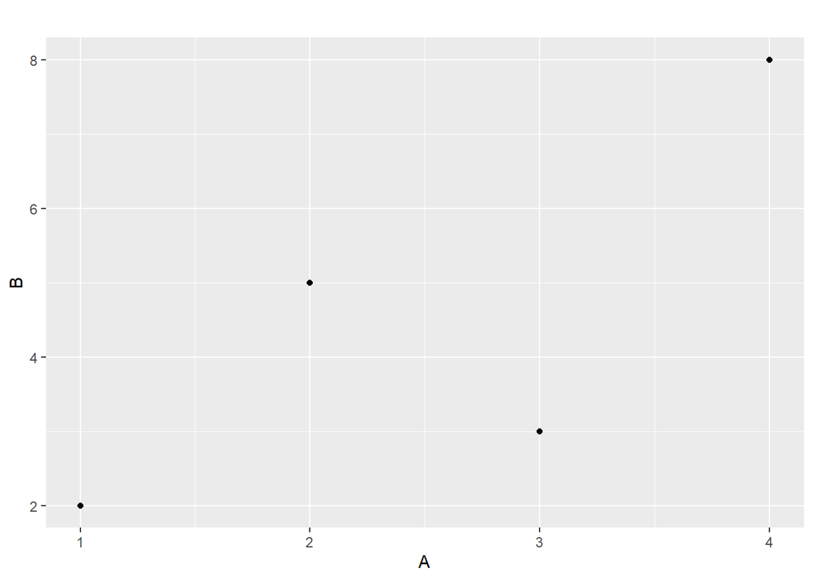

```r
ggplot(data = DATA,
       mapping = aes(x = A, y = B)
       ) +
  geom_point(mapping = aes(x = A, y = B),
             data = NULL,
             stat = "identity",
             position = "identity",
             size = 1.5,
             color = "black") +
  scale_x_continuous() +
  scale_y_continuous() +
  labs(title = "") +
  xlab("A") +
  ylab("B") +
  coord_cartesian() +
  theme()
```

Notice the plot is the same. The take-home message is that each visualization uses a data set which will be used to provide some aesthetic mapping. That mapping takes some geometric form, or geom. The geom needs information about the data, the statistical transformation (or an its ‘identity’ in the data frame), some position in space, some size, and some color. Also the axes have labels and follow some rules about their scaling. All of this follows some coordinate system. A theme is also used to decorate the plot in different ways. The default is `theme()`.

*Change the coordinate system, color, and labels*

If we wanted to change the coordinate system, then the visualization would look much different. We can also change the color and label names. And because they are independent layers, we could add them in different orders.

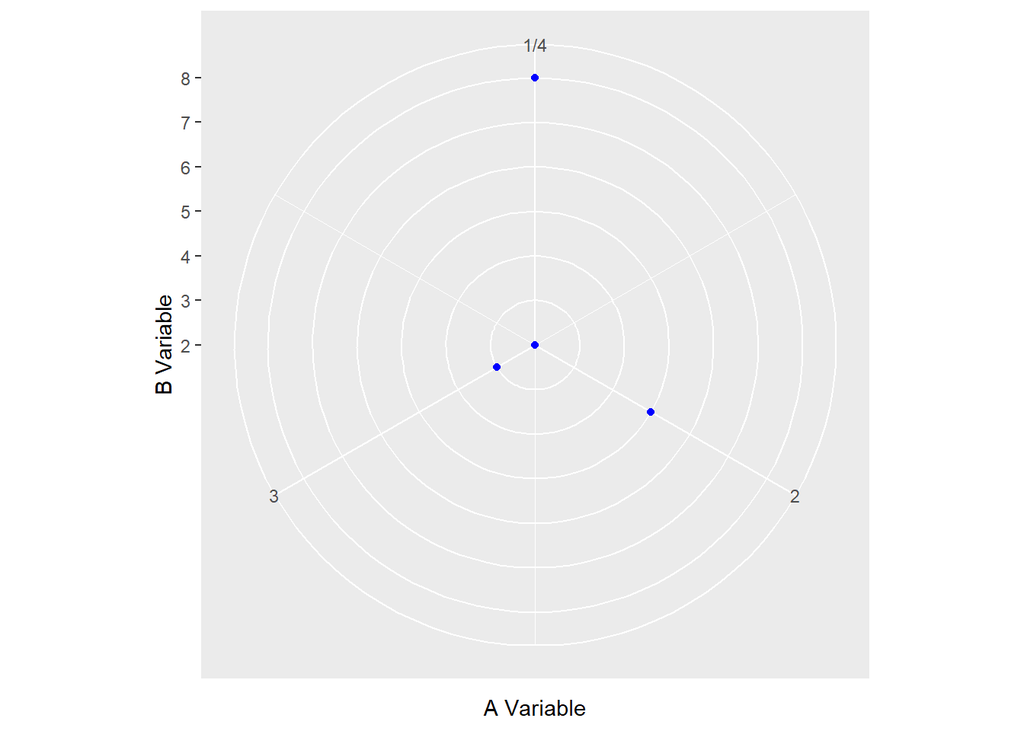

```r
ggplot(data = DATA,
       mapping = aes(x = A, y = B)
       ) +
  geom_point(mapping = aes(x = A, y = B),
             data = NULL,
             stat = "identity",
             position = "identity",
             size = 1.5,
             color = "blue") +
  coord_polar() +
  xlab("A Variable") +
  ylab("B Variable") +
  scale_x_continuous() +
  scale_y_continuous() +
  theme()
```

But because those are defaults, we don’t need to code all those plot layers. We can simply add a `geom_point()` layer. And because we pass `DATA` as the first argument and the mapping next, we could be even less wordy.

```r
ggplot(DATA, aes(x = A, y = B)) +
  geom_point()
```

# **Some Geometries and Their Aesthetics**

Not all geometries are the same. Although many geoms share most aesthetics, they don’t all have the same aesthetics. For example, a point plot doesn’t have aesthetics for a line but a line plot does. You can only add aesthetics to geoms that are understood; adding those that are not understood will, of course, throw errors.

`geom_point()` understands these aesthetics:

- x
- y
- alpha
- color
- fill
- group
- shape
- size
- stroke

`geom_line()` understands these aesthetics:

`geom_bar()` understands these aesthetics:

`geom_col()` understands these aesthetics:

- x
- y
- alpha
- color
- fill
- group
- linetype
- size

# **Adding Aesthetics That A Geometry Does not Understand**

If an aesthetic is not understood by a certain geometry, we cannot pass are argument for it. For example, you cannot add a linetype to a point plot. If you want your points connected by lines, then you can add a new geom layer to the plot that contains that aesthetic. Importantly, because geoms will inherit the data and mapping from `ggplot()` by default, the line will connect the points.

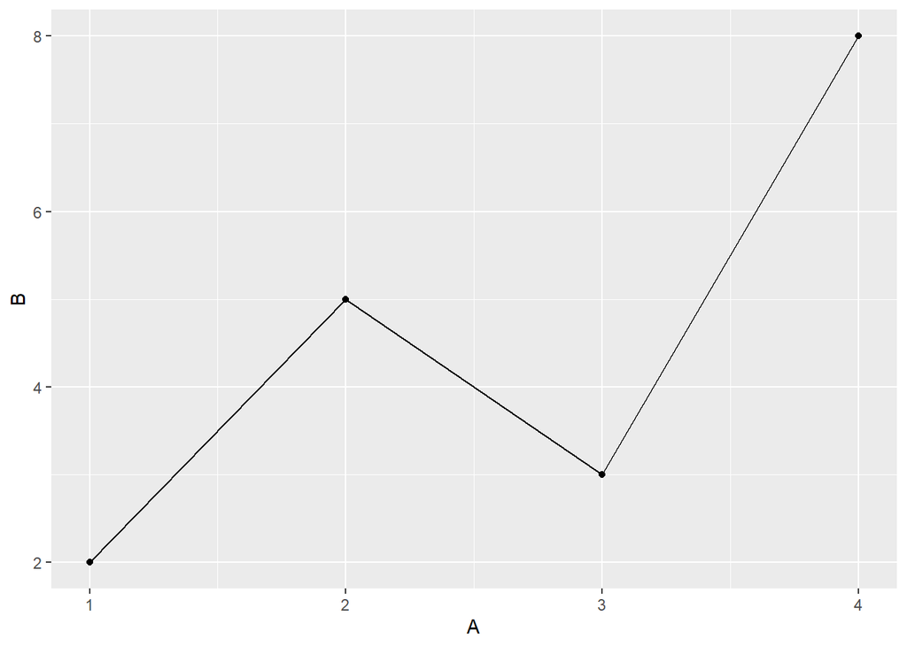

```r
ggplot(DATA, aes(x = A, y = B)) +
  geom_point() +
  geom_line()
```

And then you can change the aesthetics of `geom_line()` that it understands. More one this later.

# **Aesthetic Mapping Versus Setting**

When adding aesthetics to a geom, you may wish to make an aesthetic property like color a particular color such that all points in the point plot are the same color or you may wish the point color to vary in some way across the observations of the variable (e.g., change from cold to hot color depending on the value). Similarly, you may wish to vary the shape property with the value. You may even with the property to vary corresponding to a different variable.

- *setting* an aesthetic to a constant
- *mapping* an aesthetic to a variable

The difference between mapping and setting aesthetics all takes place either in the `aes()` function or outside the functions of the geometry. Because geometries understand certain aesthetics, the geom function has a parameter for which you can pass an argument.

Because `geom_point()` understands a `size` aesthetic because points have to take some size. The default value for size is assumed and passed in the first code block (you just don’t see it) and `size = 4` in the second code block overrides that default.

```r
ggplot(data = DATA, aes(x = A, y = B)) +
  geom_point()
```

[output not shown]

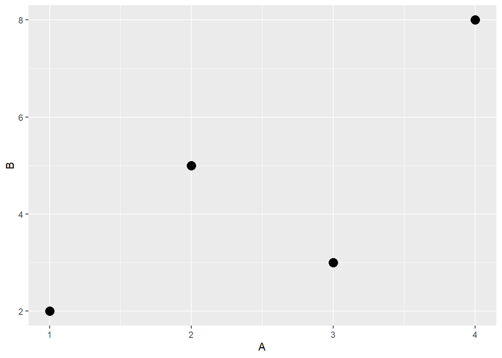

```r
ggplot(data = DATA, aes(x = A, y = B)) +
  geom_point(size = 4)
```

By passing `size = 4`, we have *set* size to a *constant* value. Not that at size was not passed inside an `aes()` function. It it were, something completely different would happen.

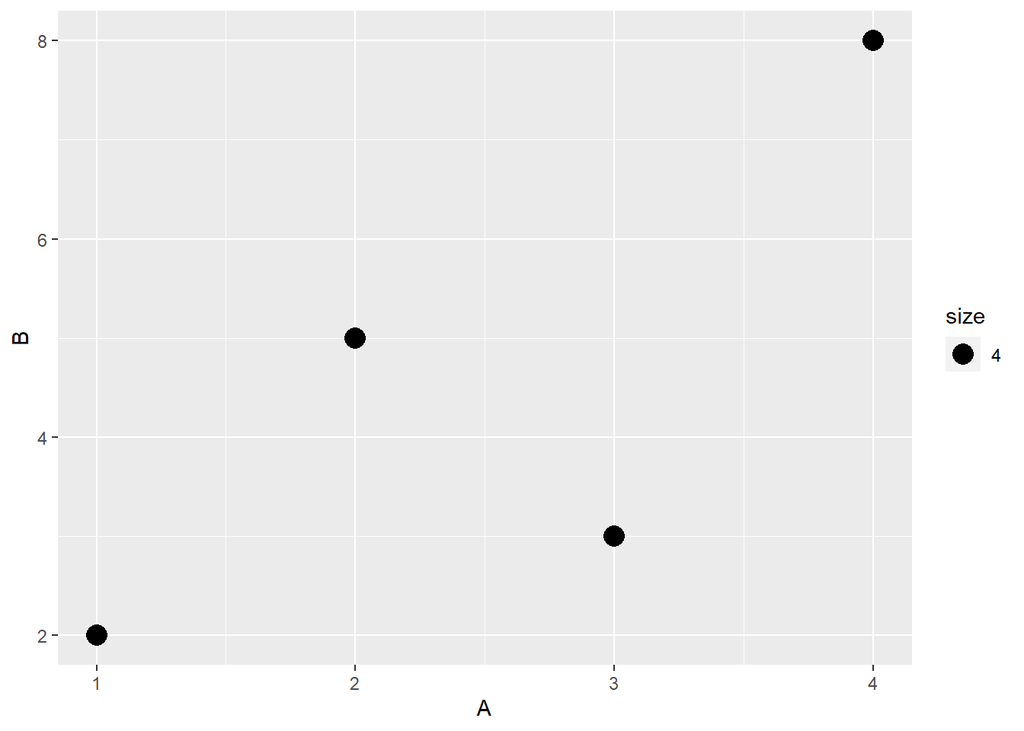

```r
ggplot(data = DATA, aes(x = A, y = B)) +
  geom_point(aes(size = 4))
```

And this is illustrated even better with the `color` aesthetic.

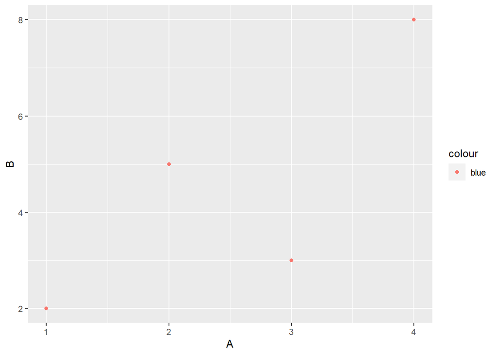

```r
ggplot(data = DATA, aes(x = A, y = B)) +
  geom_point(aes(color = "blue"))
```

In both examples, you notice that a legend not appears in the plot and in the color example, the color is not blue. Without getting into the details of what ggplot is doing, when this happens, it serves as a warning that you did something incorrectly.

Importantly, you can only *set constant values* to aesthetics outside of `aes()`. Inside of `aes()`, you *map variables* to aesthetics. Where are the variables? Well, in the data frame. By passing a different variable column form `DATA`, we can *map* the aesthetic to that *variable* so that it changes relative to the changes in the variable. The plot will also change in a variety of ways simply by adding a new variable. Let’s begin with a baseline plot for comparison and then map variables.

```r
ggplot(data = DATA, aes(x = A, y = B)) +
  geom_point()
```

## *Mapping a new variable…*

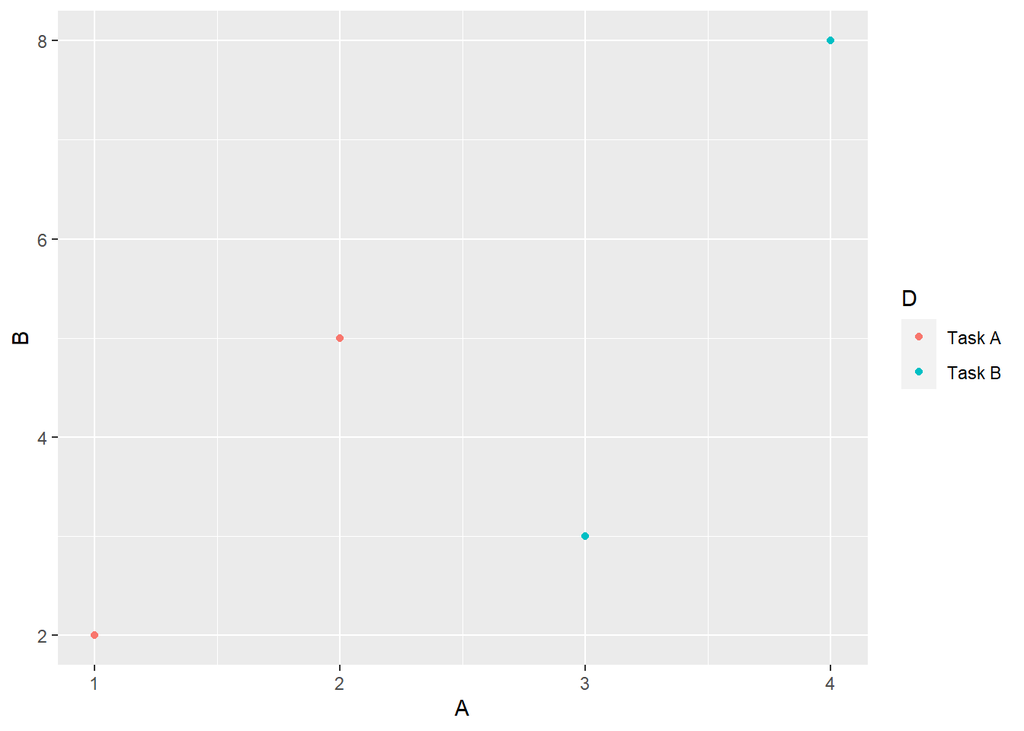

```r
ggplot(data = DATA, aes(x = A, y = B)) +
  geom_point(aes(color = D))
```

## *Mapping an existing variable…*

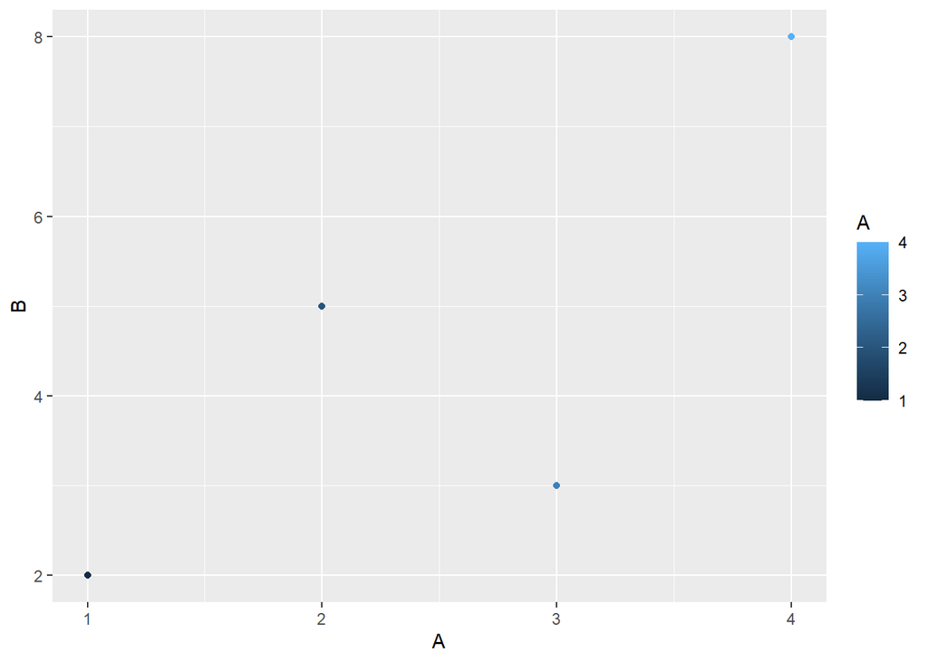

```r
ggplot(data = DATA, aes(x = A, y = B)) +
  geom_point(aes(color = A))
```

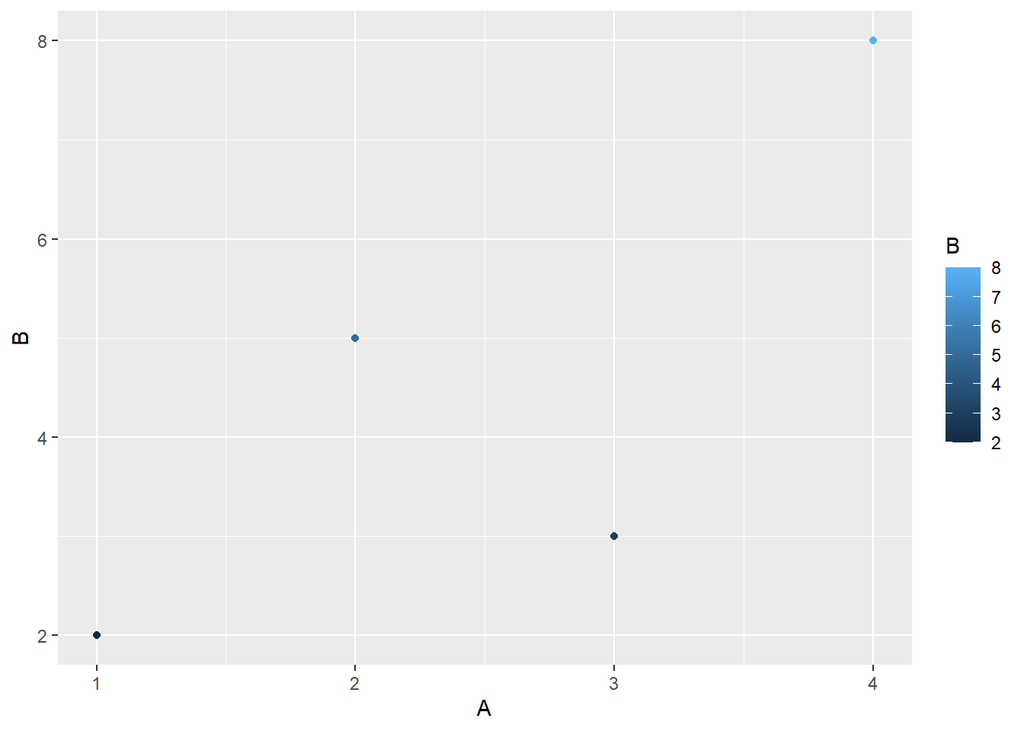

```r
ggplot(data = DATA, aes(x = A, y = B)) +
  geom_point(aes(color = B))
```

You may have noticed that when mapped variables are numeric, the aesthetics are applied continuously and when they are categorical, they are applied discretely. Here is a good example of mapping variable `A` not as itself but by changing it to a `factor()` or a character vector.

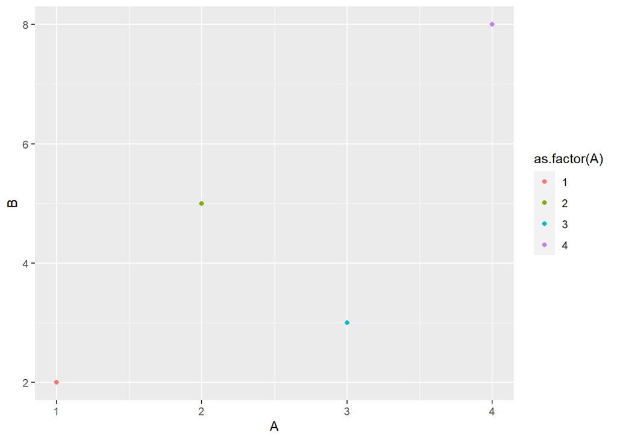

```r
ggplot(data = DATA, aes(x = A, y = B)) +
  geom_point(aes(color = as.factor(A)))
```

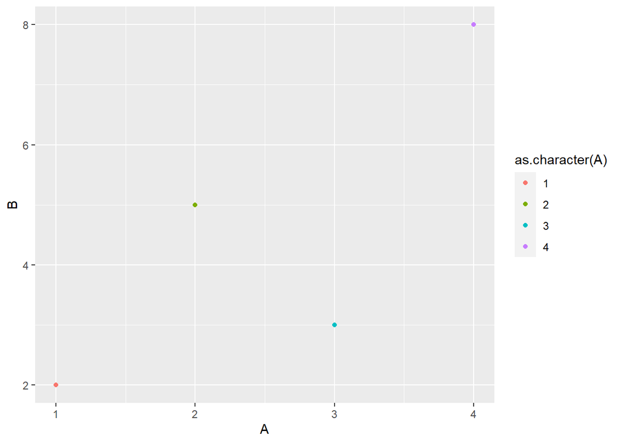

```r
ggplot(data = DATA, aes(x = A, y = B)) +
  geom_point(aes(color = as.character(A)))
```

## *Setting and Mapping Combinations*

We can also combine setting aesthetics and mapping them as long as mappings are inside `aes()` and settings are not.

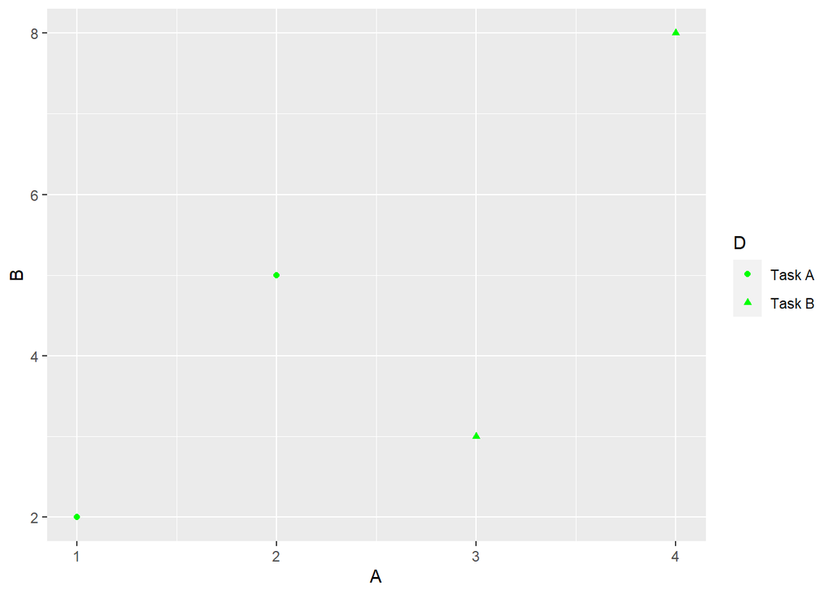

```r
ggplot(data = DATA, aes(x = A, y = B)) +
  geom_point(color = "green", aes(shape = D))
```

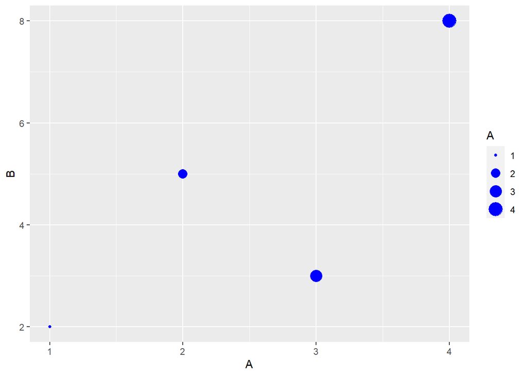

```r
ggplot(data = DATA, aes(x = A, y = B)) +
  geom_point(color = "blue", aes(size = A))
```

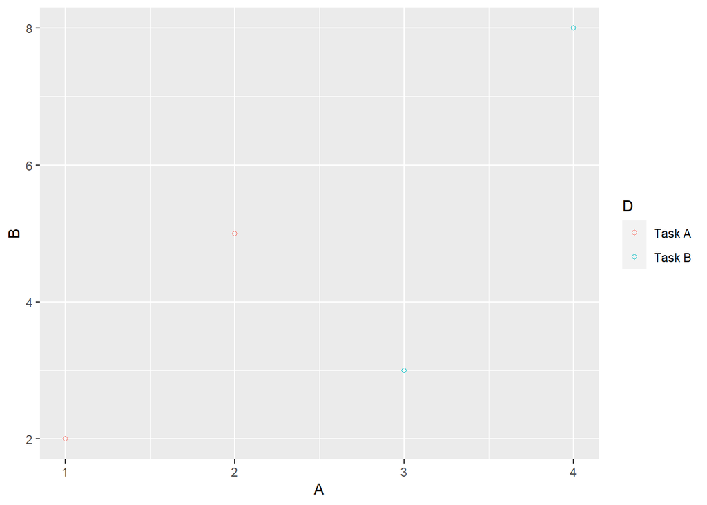

```r
ggplot(data = DATA, aes(x = A, y = B)) +
  geom_point(shape = 21, aes(color = D))
```

Importantly, just as you cannot pass constant values to aesthetics in `aes()`, you cannot pass a variable to an aesthetic in the geom function *unless* it is inside `aes()`.

`ggplot(data = DATA, aes(x = A, y = B)) +` `geom_point(color = A))`

`Error: unexpected ')' in:` `"ggplot(data = DATA, aes(x = A, y = B)) +` `geom_point(color = A))"`

In summary, when you want to set an aesthetic to a constant value, do so in the geometry function (e.g., `geom_point()`), otherwise, pass an `aes()` to the geometry function. Color options can be discovered using `colors()`. Linetype has fewer options. To make the color more or less transparent, adjust alpha (from 0 = invisible to 1).

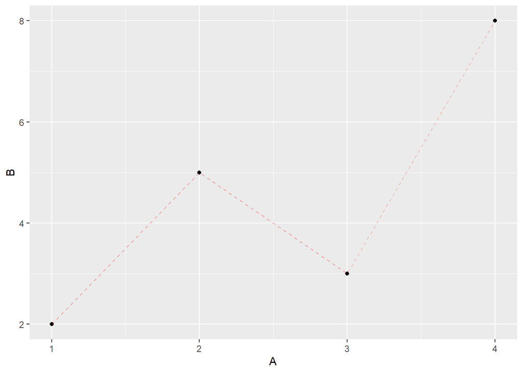

```r
ggplot(DATA, aes(x = A, y = B)) +
  geom_point() +
  geom_line(linetype = "dashed",
            color = "red",
            alpha = .3)
```